# **Instacart**

The student is invited to make themselves familiar with the dataset containing the purchase history for a supply chain store[1]. Let's say store planners are about to launch a series of promotions. Launching actions panners want to take into account the expected changes in sales of linked products (implicit bundle) in order to optimize the stock. Could you generate rules based on the dataset with high confidence or lift but low support?

Apart from that, could you define isolated product groups/clusters? How it could help the planners in terms of value function / business value? What products can increase customer engagement in the selection process?

For Spark-positive, users it’s recommended to use inner ML packages, in the case of Pandas-positive performers we propose Mlxtend package. In case of lack of computing resources, use sampling. Exploratory data analysis is the assessed part of the assignment.

**Success criteria**

- The minimum required support level is estimated
- Non-trivial patterns are given
- Customer segments explained; audience coverage by pattern is provided
- Products that increase customer loyalty are shown

### **Imports**

```python
!pip install pyspark
!pip install pyspark_dist_explore
!pip install yellowbrick
```

```
     |████████████████████████████████| 281.4 MB 34 kB/s
     |████████████████████████████████| 198 kB 37.5 MB/s
```

```python
import pyspark
from pyspark import SparkContext
from pyspark.sql import SQLContext
from pyspark.sql.functions import col
from pyspark.sql import SparkSession
from pyspark.sql import functions as F
from pyspark.ml.feature import VectorAssembler
from pyspark.sql.types import DoubleType
from pyspark.ml.classification import RandomForestClassifier, GBTClassifier, LogisticRegression
from pyspark.ml.evaluation import BinaryClassificationEvaluator
from pyspark.ml.tuning import CrossValidator, ParamGridBuilder
from pyspark.ml.feature import VectorSlicer
from pyspark.ml.linalg import Vectors
from pyspark.sql.functions import udf,when
from pyspark.sql import functions as f, SparkSession, Column
from pyspark_dist_explore import hist
from pyspark.ml.fpm import FPGrowth

import os
import zipfile
import time
import pandas as pd
import numpy as np

import warnings
warnings.simplefilter('ignore')

%matplotlib inline
import seaborn as sns
import matplotlib.pyplot as plt
sns.set_context('talk')
sns.set(style="ticks")

import sqlite3

import scipy.stats as stats

from statsmodels.stats.power import TTestIndPower, TTestPower

from sklearn.preprocessing import StandardScaler
from sklearn.cluster import KMeans
from sklearn.manifold import TSNE
from sklearn.metrics import silhouette_score

from yellowbrick.cluster import KElbowVisualizer
```

### **Functions**

```python
# test KMeans at various k (silhouette score)
def optimal_kmeans(dataset, start=2, end=11):
    '''
    Calculate the optimal number of kmeans

    Params:
        dataset : dataframe. Dataset for k-means to fit
        start : int. Starting range of kmeans to test
        end : int. Ending range of kmeans to test
    Return:
        Values and line plot of Silhouette Score.
    '''

    # Create empty lists to store values for plotting graphs
    n_clu = []
    km_ss = []

    # Create a for loop to find optimal n_clusters
    for n_clusters in range(start, end):

        # Create cluster labels
        kmeans = KMeans(n_clusters=n_clusters)
        labels = kmeans.fit_predict(dataset)

        # Calcualte model performance
        silhouette_avg = round(silhouette_score(dataset, labels,
                                                random_state=1), 3)

        # Append score to lists
        km_ss.append(silhouette_avg)
        n_clu.append(n_clusters)

        print("No. Clusters: {}, Silhouette Score: {}, Change from Previous Cluster: {}".format(
            n_clusters,
            silhouette_avg,
            (km_ss[n_clusters - start] - km_ss[n_clusters - start - 1]).round(3)))

        # Plot graph at the end of loop
        if n_clusters == end - 1:
            plt.figure(figsize=(4,4))

            plt.title('Silhouette Score Elbow for KMeans Clustering')
            plt.xlabel('k')
            plt.ylabel('silhouette score')
            sns.pointplot(x=n_clu, y=km_ss)
            plt.savefig('silhouette_score.png', format='png', dpi=300,
                        pad_inches=2.0)
            plt.tight_layout()
            plt.show()
```

```python
# calculate and plot specified # of clusters
def kmeans(df, clusters_number):
    '''
    Implement k-means clustering on dataset

    INPUT:
        dataset : dataframe. Dataset for k-means to fit.
        clusters_number : int. Number of clusters to form.
        end : int. Ending range of kmeans to test.
    OUTPUT:
        Cluster results and t-SNE visualisation of clusters.
    '''
    kmeans = KMeans(n_clusters = clusters_number, random_state = 1)
    kmeans.fit(df)

    # Extract cluster labels
    cluster_labels = kmeans.labels_

    # Create a cluster label column in original dataset
    df_new = df.assign(Cluster = cluster_labels)

    # Initialise TSNE
    model = TSNE(random_state=1)
    transformed = model.fit_transform(df)

    # Plot t-SNE

    sns.relplot(x=transformed[:,0], y=transformed[:,1],
                    hue=cluster_labels, style=cluster_labels, palette="coolwarm")

    return df_new, cluster_labels
```

### **Load data**

```python
# Create a spark session. All sorts of settings can be specified here.
spark = SparkSession.builder \
    .appName("arlUsingPyspark") \
    .getOrCreate()
```

```python
aisles = spark.read.csv("C:/Minor/EPAM_LAB/Mod2/datasets/aisles.csv", header=True, inferSchema=True)
departments = spark.read.csv("C:/Minor/EPAM_LAB/Mod2/datasets/departments.csv", header=True, inferSchema=True)
order_products_train = spark.read.csv("C:/Minor/EPAM_LAB/Mod2/datasets/order_products__train.csv", header=True, inferSchema=True)
orders = spark.read.csv("C:/Minor/EPAM_LAB/Mod2/datasets/orders.csv", header=True, inferSchema=True)
products = spark.read.csv("C:/Minor/EPAM_LAB/Mod2/datasets/products.csv", header=True, inferSchema=True)

aisles.createOrReplaceTempView("aisles")
departments.createOrReplaceTempView("departments")
order_products_train.createOrReplaceTempView("order_products_train")
orders.createOrReplaceTempView("orders")
products.createOrReplaceTempView("products")
```

```python
orders.show(n=5)
```

```
+--------+-------+--------+------------+---------+-----------------+----------------------+
|order_id|user_id|eval_set|order_number|order_dow|order_hour_of_day|days_since_prior_order|
+--------+-------+--------+------------+---------+-----------------+----------------------+
| 2539329|      1|   prior|           1|        2|                8|                  null|
| 2398795|      1|   prior|           2|        3|                7|                  15.0|
|  473747|      1|   prior|           3|        3|               12|                  21.0|
| 2254736|      1|   prior|           4|        4|                7|                  29.0|
|  431534|      1|   prior|           5|        4|               15|                  28.0|
+--------+-------+--------+------------+---------+-----------------+----------------------+
only showing top 5 rows
```

```python
products.show(n=5)
```

```
+----------+--------------------+--------+-------------+
|product_id|        product_name|aisle_id|department_id|
+----------+--------------------+--------+-------------+
|         1|Chocolate Sandwic...|      61|           19|
|         2|    All-Seasons Salt|     104|           13|
|         3|Robust Golden Uns...|      94|            7|
|         4|Smart Ones Classi...|      38|            1|
|         5|Green Chile Anyti...|       5|           13|
+----------+--------------------+--------+-------------+
only showing top 5 rows
```

```python
order_products_train.show(n=5)
```

```
+--------+----------+-----------------+---------+
|order_id|product_id|add_to_cart_order|reordered|
+--------+----------+-----------------+---------+
|       1|     49302|                1|        1|
|       1|     11109|                2|        1|
|       1|     10246|                3|        0|
|       1|     49683|                4|        0|
|       1|     43633|                5|        1|
+--------+----------+-----------------+---------+
only showing top 5 rows
```

```python
departments.show(n=5)
```

```
+-------------+----------+
|department_id|department|
+-------------+----------+
|            1|    frozen|
|            2|     other|
|            3|    bakery|
|            4|   produce|
|            5|   alcohol|
+-------------+----------+
only showing top 5 rows
```

```python
aisles.show(n=5)
```

```
+--------+--------------------+
|aisle_id|               aisle|
+--------+--------------------+
|       1|prepared soups sa...|
|       2|   specialty cheeses|
|       3| energy granola bars|
|       4|       instant foods|
|       5|marinades meat pr...|
+--------+--------------------+
only showing top 5 rows
```

### **Make Shopping Basket**

```python
# Organize the data by shopping basket
from pyspark.sql.functions import collect_set, col, count
rawData = spark.sql("select p.product_name, o.order_id from products p inner join order_products_train o where o.product_id = p.product_id")
baskets = rawData.groupBy('order_id').agg(collect_set('product_name').alias('items'))
baskets.createOrReplaceTempView('baskets')
```

```python
baskets.show(5)
```

```
+--------+--------------------+
|order_id|               items|
+--------+--------------------+
|     762|[Organic Cucumber...|
|     844|[Organic Red Radi...|
|     988|[Whipped Light Cr...|
|    1139|[Cinnamon Rolls w...|
|    1143|[Water, Natural P...|
+--------+--------------------+
only showing top 5 rows
```

```python
departments.unpersist()
aisles.unpersist()
products.unpersist()
orders.unpersist()
```

```
DataFrame[order_id: int, user_id: int, eval_set: string, order_number: int, order_dow: int, order_hour_of_day: int, days_since_prior_order: double]
```

### **Run PySpark's implementation of FPGrowth**

**Train ML Model**  
To understand the frequency of items are associated with each other, I'll use association rule mining for market basket analysis. I'll use FP-growth as the order information is not important for this use case.

Extract out the prod seq

```python
ubs = baskets.drop('order_id')
baskets.unpersist()
```

```
DataFrame[order_id: int, items: array<string>]
```

```python
fp = FPGrowth(minSupport=0.001, minConfidence=0.001, itemsCol='items', predictionCol='prediction')
model = fp.fit(ubs)
```

**Most Frequent Itemsets**

```python
model.freqItemsets.show(10, False)
```

```
+----------------------------------------------------------+----+
|items                                                     |freq|
+----------------------------------------------------------+----+
|[Extra Ginger Brew Jamaican Style Ginger Beer]            |259 |
|[Whole Strawberries]                                      |365 |
|[Organic Lime]                                            |140 |
|[Chopped Tomatoes]                                        |159 |
|[Low Fat Plain Yogurt]                                    |200 |
|[Organic Tomato Basil Pasta Sauce]                        |772 |
|[Organic Tomato Basil Pasta Sauce, Bag of Organic Bananas]|175 |
|[Organic Tomato Basil Pasta Sauce, Organic Baby Spinach]  |144 |
|[Organic Tomato Basil Pasta Sauce, Banana]                |179 |
|[Thin & Light Tortilla Chips]                             |301 |
+----------------------------------------------------------+----+
only showing top 10 rows
```

**View Generated Association Rules**

```python
# Use filter to view just the association rules with the highest confidence.
model.associationRules.filter(model.associationRules.confidence>0.15).show(20, False)
```

```
+--------------------------+------------------------+-------------------+------------------+---------------------+
|antecedent                |consequent              |confidence         |lift              |support              |
+--------------------------+------------------------+-------------------+------------------+---------------------+
|[Trilogy Kombucha Drink]  |[Bag of Organic Bananas]|0.21739130434782608|1.8426159982024493|0.0010669999771357147|
|[Organic Shredded Carrots]|[Organic Strawberries]  |0.163855421686747  |1.9734997268309513|0.0010365142635032657|
|[Organic Shredded Carrots]|[Bag of Organic Bananas]|0.1891566265060241 |1.6032979203636253|0.001196564260073623 |
|[Organic Shredded Carrots]|[Organic Baby Spinach]  |0.24819277108433735|3.328406101921997 |0.001570014252071123 |
|[Organic Shredded Carrots]|[Banana]                |0.22409638554216868|1.570194523689117 |0.0014175856839088782|
|[Green Bell Pepper]       |[Red Peppers]           |0.1915906386354621 |8.653499519697194 |0.003681149921118216 |
|[Green Bell Pepper]       |[Bag of Organic Bananas]|0.15351051170170568|1.301160253867513 |0.00294949279393944  |
|[Green Bell Pepper]       |[Organic Baby Spinach]  |0.15390717969059897|2.0639827412125715|0.0029571142223475525|
|[Green Bell Pepper]       |[Banana]                |0.24276080920269735|1.7009720717012022|0.004664314185764696 |
|[Organic Garlic, Banana]  |[Limes]                 |0.21568627450980393|4.690863648625371 |0.0011736999748492862|
|[Organic Garlic, Banana]  |[Organic Strawberries]  |0.18487394957983194|2.2266500872425343|0.0010060285498708168|
|[Organic Garlic, Banana]  |[Organic Avocado]       |0.2759103641456583 |4.88620906589117  |0.0015014213963981129|
|[Organic Garlic, Banana]  |[Large Lemon]           |0.2913165266106443 |4.698629396442043 |0.0015852571088873476|
|[Organic Garlic, Banana]  |[Organic Baby Spinach]  |0.2661064425770308 |3.568638616525923 |0.001448071397541327 |
|[Organic Ginger Root]     |[Organic Cilantro]      |0.15346287992027902|5.710638403703883 |0.0023473999496985724|
|[Organic Ginger Root]     |[Limes]                 |0.15844544095665172|3.4459585384520666|0.002423614233779695 |
|[Organic Ginger Root]     |[Large Lemon]           |0.16143497757847533|2.6037765178972547|0.0024693428042283686|
|[Organic Ginger Root]     |[Bag of Organic Bananas]|0.24265072247135028|2.0567156747250257|0.003711635634750665 |
|[Organic Ginger Root]     |[Organic Baby Spinach]  |0.2341803687095167 |3.140491823181416 |0.003582071351812757 |
|[Organic Ginger Root]     |[Organic Garlic]        |0.22122571001494767|6.980953387530368 |0.003383914213201838 |
+--------------------------+------------------------+-------------------+------------------+---------------------+
only showing top 20 rows
```

Create a prediction based on the generated association rules:

Prepare data

```python
order_products_prior = spark.read.csv("C:/Minor/EPAM_LAB/Mod2/datasets/order_products__prior.csv", header=True, inferSchema=True)
order_products_prior.createOrReplaceTempView("order_products_prior")
```

```python
rawData = spark.sql("select p.product_name, o.order_id from products p inner join order_products_prior o where o.product_id = p.product_id")
baskets = rawData.groupBy('order_id').agg(collect_set('product_name').alias('items'))
baskets.createOrReplaceTempView('baskets')
```

```python
# limited_df = order_products_prior.limit(2000000)
```

```python
order_products_prior.unpersist()
```

```
DataFrame[order_id: int, product_id: int, add_to_cart_order: int, reordered: int]
```

```python
ubs = baskets.drop('order_id')
```

```python
ubs.show(5)
```

```
+--------------------+
|               items|
+--------------------+
|[Original Semisof...|
|[Organic Cilantro...|
|[Organic Original...|
|[Soy Sauce, Organ...|
|[Roasted Pine Nut...|
+--------------------+
only showing top 5 rows
```

```python
baskets.unpersist()
```

```
DataFrame[order_id: int, items: array<string>]
```

```python
# limited_ub = ubs.limit(100)
```

**Predict**  
Now that we have a new PySpark dataframe with data, predict. The first basket generates numerous predictions based on the association rules.

```python
model.transform(ubs).show(5, False)
```

```
+-----------------------------------------------------------------------------------------------------------------------------------------------------------------------------------------------------------------------------------------------------------------------------------------------------------…
|items                                                                                                                                                                                                                                                                                                      …
+-----------------------------------------------------------------------------------------------------------------------------------------------------------------------------------------------------------------------------------------------------------------------------------------------------------…
|[Original Semisoft Cheese, Large Greenhouse Tomato, Organic Black Plum, Cream Cheese, Organic Red Delicious Apple, Salted Butter, Organic Strawberry Fruit Spread, Cultured Low Fat Buttermilk, Air Chilled Organic Boneless Skinless Chicken Breasts, Organic Whole Milk Strawberry Beet Berry Yogurt Pouc…
|[Organic Cilantro, Uncured, No Sugar, Hickory Smoked Bacon, Organic Baby Spinach, Organic Yellow Onion, Organic Whole Grain Sprouted Quinoa, Heirloom Tomato, Organic Vidalia Onion, Roasted & Salted Almonds, Earl Grey Tea, Seedless Red Grapes]                                                         …
|[Organic Original Tofu Veggie Burger, Sprouted Multi-Grain Bread, Organic Blueberries, Banana, Organic Raw Sharp Cheddar Cheese, Burrata, Large Lemon, Sweet Baguette, Organic Gala Apples, Original Veggie Straws, Organic Grape Tomatoes, Organic Traditional Flour Tortillas, Organic Hass Avocado, Orga…
|[Soy Sauce, Organic 1% Lowfat Milk, Organic 2% Reduced Fat Milk]                                                                                                                                                                                                                                           …
|[Roasted Pine Nut Hummus, Fresh Mozzarella All-Natural Sliced Cheese, Fat Free Skim Milk, Strawberries, Whole Grain Cheddar Baked Snack Crackers]                                                                                                                                                          …
+-----------------------------------------------------------------------------------------------------------------------------------------------------------------------------------------------------------------------------------------------------------------------------------------------------------…
only showing top 5 rows
```

# **Customer segmentation (RFM like)**

### **Load datasets**

```python
aisles_df = pd.read_csv('/content/drive/My Drive/ЛАБ/MOD_2/datasets/aisles/aisles.csv',
                       engine='c')

departments_df =  pd.read_csv("/content/drive/My Drive/ЛАБ/MOD_2/datasets/departments/departments.csv",
                             engine='c')

order_TRAIN_df = pd.read_csv("/content/drive/My Drive/ЛАБ/MOD_2/datasets/order_products__train/order_products__train.csv",
                             engine='c',
                             dtype={'reordered':np.int8,
                                     'add_to_cart_order':np.int16})

orders_df = pd.read_csv("/content/drive/My Drive/ЛАБ/MOD_2/datasets/orders/orders.csv",
                       engine='c')

op_prior = pd.read_csv('/content/drive/My Drive/ЛАБ/MOD_2/datasets/order_products__prior/order_products__prior.csv',
                       engine='c',
                       dtype={'order_id': np.int32,
                              'product_id': np.int32,
                              'add_to_cart_order': np.int16,
                              'reordered': np.int8})

products_df =  pd.read_csv("/content/drive/My Drive/ЛАБ/MOD_2/datasets/products/products.csv",
                          engine='c')
```

**Optimize memory**

```python
orders_df['order_dow'] = orders_df['order_dow'].astype(np.int8)
orders_df['order_hour_of_day']= orders_df['order_hour_of_day'].astype(np.int8)
orders_df['order_number'] = orders_df['order_number'].astype(np.int16)
orders_df['order_id'] = orders_df['order_id'].astype(np.int32)
orders_df['user_id'] = orders_df['user_id'].astype(np.int32)
orders_df['days_since_prior_order'] = orders_df['days_since_prior_order'].astype(np.float32)
```

```python
# products_df.drop(['product_name'], axis=1, inplace=True)
products_df['aisle_id'] = products_df['aisle_id'].astype(np.int8)
products_df['department_id'] = products_df['department_id'].astype(np.int8)
products_df['product_id'] = products_df['product_id'].astype(np.int32)
```

### **Look at users and their characteristic**

If I can figure out a way to easily sort the customers in meaningful segments, a marketing department could use that information to plan campaigns targeted to the needs and opportunities of each segment. I'll use k-means clustering to do this.

**Inspect the records of an individual user**

```python
orders_df.drop(['eval_set'], axis=1, inplace=True)
```

```python
# Inspect the records of an individual user
user_2 = orders_df[orders_df.user_id == 2]
user_2
```

|  | order_id | user_id | order_number | order_dow | order_hour_of_day | days_since_prior_order |
| --- | --- | --- | --- | --- | --- | --- |
| 11 | 2168274 | 2 | 1 | 2 | 11 | NaN |
| 12 | 1501582 | 2 | 2 | 5 | 10 | 10.0 |
| 13 | 1901567 | 2 | 3 | 1 | 10 | 3.0 |
| 14 | 738281 | 2 | 4 | 2 | 10 | 8.0 |
| 15 | 1673511 | 2 | 5 | 3 | 11 | 8.0 |
| 16 | 1199898 | 2 | 6 | 2 | 9 | 13.0 |
| 17 | 3194192 | 2 | 7 | 2 | 12 | 14.0 |
| 18 | 788338 | 2 | 8 | 1 | 15 | 27.0 |
| 19 | 1718559 | 2 | 9 | 2 | 9 | 8.0 |
| 20 | 1447487 | 2 | 10 | 1 | 11 | 6.0 |
| 21 | 1402090 | 2 | 11 | 1 | 10 | 30.0 |
| 22 | 3186735 | 2 | 12 | 1 | 9 | 28.0 |
| 23 | 3268552 | 2 | 13 | 4 | 11 | 30.0 |
| 24 | 839880 | 2 | 14 | 3 | 10 | 13.0 |
| 25 | 1492625 | 2 | 15 | 1 | 11 | 30.0 |

```python
# how .mean() will handle the NaN at every first order
user_2.days_since_prior_order.mean()
```

```
16.285715103149414
```

```
No handles with labels found to put in legend.
```

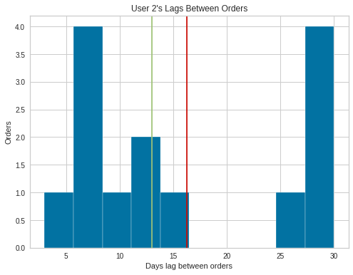

```python
# Visualize distribution of user's lags between orders
plt.figure(figsize=(8,6))
plt.hist(user_2.days_since_prior_order)
plt.axvline(user_2.days_since_prior_order.mean(), color='r')
plt.axvline(user_2.days_since_prior_order.median(), color='g')
plt.xlabel('Days lag between orders')
plt.ylabel('Orders')
plt.title('User 2\'s Lags Between Orders')
plt.legend()
plt.show();
```

### **Feature engineering**

In the absence of data I can use for an RFM (recency, frequency, monetary) analysis, I'll need to engineer some features that I think will be meaningful. Here's what I want to try:

For each customer:

- total number of orders
- mean lag between orders
- mean number of products per order
- median hour of order
- rate of peak-day ordering
- rate of peak-time ordering

I'll try clustering three times: once with this full feature set, once with the first three features, and once with the last three features. The first three features are the most similar to RFM.

**Acquire needed data**

Here I gather and transform the data I need to make the features outlined above.

```python
order_products_train_df = pd.merge(order_TRAIN_df, orders_df, on='order_id', how='left')
```

```python
order_products_train_df.head()
```

|  | order_id | product_id | add_to_cart_order | reordered | user_id | eval_set | order_number | order_dow | order_hour_of_day | days_since_prior_order |
| --- | --- | --- | --- | --- | --- | --- | --- | --- | --- | --- |
| 0 | 1 | 49302 | 1 | 1 | 112108 | train | 4 | 4 | 10 | 9.0 |
| 1 | 1 | 11109 | 2 | 1 | 112108 | train | 4 | 4 | 10 | 9.0 |
| 2 | 1 | 10246 | 3 | 0 | 112108 | train | 4 | 4 | 10 | 9.0 |
| 3 | 1 | 49683 | 4 | 0 | 112108 | train | 4 | 4 | 10 | 9.0 |
| 4 | 1 | 43633 | 5 | 1 | 112108 | train | 4 | 4 | 10 | 9.0 |

```python
group = order_products_train_df.groupby('order_id')['product_id'].count()
prod_counts =  pd.DataFrame(group, index=group.index)
```

```python
prod_counts.rename(columns={'product_id': 'num_products'}, inplace=True)
prod_counts.head()
```

| order_id | num_products |
| --- | --- |
| 1 | 8 |
| 36 | 8 |
| 38 | 9 |
| 96 | 7 |
| 98 | 49 |

```python
# Join orders to prod_counts
user_data = orders_df.join(prod_counts, how='inner', on='order_id')
user_data.head()
```

|  | order_id | user_id | eval_set | order_number | order_dow | order_hour_of_day | days_since_prior_order | num_products |
| --- | --- | --- | --- | --- | --- | --- | --- | --- |
| 10 | 1187899 | 1 | train | 11 | 4 | 8 | 14.0 | 11 |
| 25 | 1492625 | 2 | train | 15 | 1 | 11 | 30.0 | 31 |
| 49 | 2196797 | 5 | train | 5 | 0 | 11 | 6.0 | 9 |
| 74 | 525192 | 7 | train | 21 | 2 | 11 | 6.0 | 9 |
| 78 | 880375 | 8 | train | 4 | 1 | 14 | 10.0 | 18 |

Calculate total number of orders per customer

```python
# Calculate total number of orders per customer
num_orders = user_data.groupby('user_id')['order_number'].max()
```

Calculate rate at which each customer orders on peak days

```python
# Create boolean column to record whether order occurred on a peak day
user_data['order_on_peak'] = np.where(user_data['order_dow'] <=1, 1, 0)
user_data.head()
```

|  | order_id | user_id | eval_set | order_number | order_dow | order_hour_of_day | days_since_prior_order | num_products | order_on_peak |
| --- | --- | --- | --- | --- | --- | --- | --- | --- | --- |
| 10 | 1187899 | 1 | train | 11 | 4 | 8 | 14.0 | 11 | 0 |
| 25 | 1492625 | 2 | train | 15 | 1 | 11 | 30.0 | 31 | 1 |
| 49 | 2196797 | 5 | train | 5 | 0 | 11 | 6.0 | 9 | 1 |
| 74 | 525192 | 7 | train | 21 | 2 | 11 | 6.0 | 9 | 0 |
| 78 | 880375 | 8 | train | 4 | 1 | 14 | 10.0 | 18 | 1 |

```python
# Calculate rate of peak day ordering per customer
peakday_rate = round(user_data.groupby('user_id')['order_on_peak'].mean(), 2)
peakday_rate.value_counts()
```

```
0.0    84072
1.0    47137
Name: order_on_peak, dtype: int64
```

Calculate median hour of day at which each customer places their orders

```python
# Calculate median ordering hour per user
med_hour = round(user_data.groupby('user_id')['order_hour_of_day'].median(), 0)
med_hour.head()
```

```
user_id
1     8.0
2    11.0
5    11.0
7    11.0
8    14.0
Name: order_hour_of_day, dtype: float64
```

Calculate rate at which each customer orders during peak hours

```python
# Create boolean column to record whether order occured during peak hours
# Peak hours defined as interquartile range of order times
user_data['peak_time'] = np.where((user_data.order_hour_of_day >= 10)
                                  & (user_data.order_hour_of_day <= 16), 1, 0)
user_data.head()
```

|  | order_id | user_id | eval_set | order_number | order_dow | order_hour_of_day | days_since_prior_order | num_products | order_on_peak | peak_time |
| --- | --- | --- | --- | --- | --- | --- | --- | --- | --- | --- |
| 10 | 1187899 | 1 | train | 11 | 4 | 8 | 14.0 | 11 | 0 | 0 |
| 25 | 1492625 | 2 | train | 15 | 1 | 11 | 30.0 | 31 | 1 | 1 |
| 49 | 2196797 | 5 | train | 5 | 0 | 11 | 6.0 | 9 | 1 | 1 |
| 74 | 525192 | 7 | train | 21 | 2 | 11 | 6.0 | 9 | 0 | 1 |
| 78 | 880375 | 8 | train | 4 | 1 | 14 | 10.0 | 18 | 1 | 1 |

```python
# Calculate rate of peak time ordering per customer
peaktime_rate = round(user_data.groupby('user_id')['peak_time'].mean(), 2)
peaktime_rate.value_counts()
```

```
1.0    75201
0.0    56008
Name: peak_time, dtype: int64
```

Calculate average lag between orders per customer

```python
# Calculate mean lag per customer
mean_lag = round(user_data.groupby('user_id')['days_since_prior_order'].mean(), 0)
mean_lag.head()
```

```
user_id
1    14.0
2    30.0
5     6.0
7     6.0
8    10.0
Name: days_since_prior_order, dtype: float32
```

Calculate mean number of products ordered per customer

```python
# Calculate mean products ordered per customer
mean_products = round(user_data.groupby('user_id')['num_products'].mean(), 0)
mean_products.head()
```

```
user_id
1    11.0
2    31.0
5     9.0
7     9.0
8    18.0
Name: num_products, dtype: float64
```

Concatenate all the new features

```python
features = pd.concat([num_orders, peakday_rate, med_hour, peaktime_rate,
                      mean_lag, mean_products], axis=1)
features.columns = ['num_orders', 'peakday_rate', 'med_hour', 'peaktime_rate',
                    'mean_lag', 'mean_products']
features.head()
```

| user_id | num_orders | peakday_rate | med_hour | peaktime_rate | mean_lag | mean_products |
| --- | --- | --- | --- | --- | --- | --- |
| 1 | 11 | 0.0 | 8.0 | 0.0 | 14.0 | 11.0 |
| 2 | 15 | 1.0 | 11.0 | 1.0 | 30.0 | 31.0 |
| 5 | 5 | 1.0 | 11.0 | 1.0 | 6.0 | 9.0 |
| 7 | 21 | 0.0 | 11.0 | 1.0 | 6.0 | 9.0 |
| 8 | 4 | 1.0 | 14.0 | 1.0 | 10.0 | 18.0 |

Check for missing values

```python
features.isna().sum()
```

```
num_orders       0
peakday_rate     0
med_hour         0
peaktime_rate    0
mean_lag         0
mean_products    0
dtype: int64
```

Visualize distribution of each feature

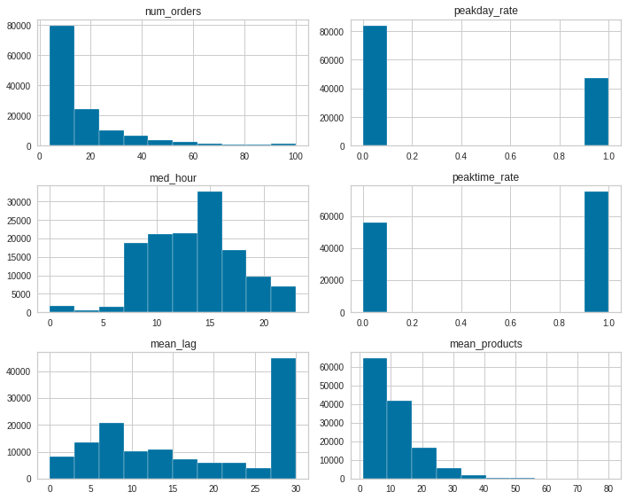

```python
features.hist(figsize=(10,8))
plt.tight_layout();
```

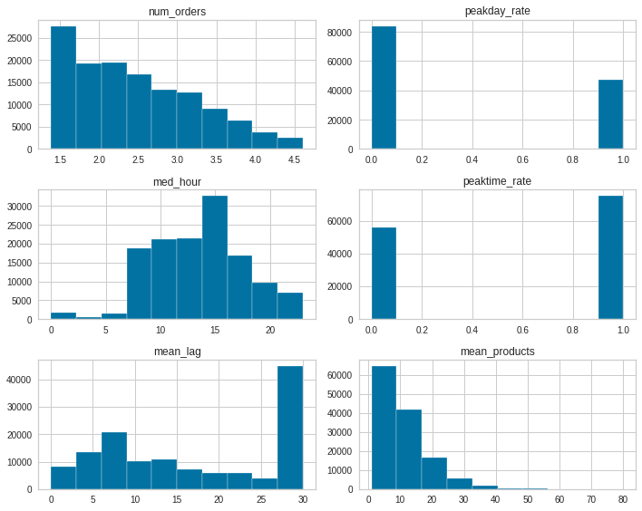

```python
# Log-transform `num_orders` and replot features
features['num_orders'] = np.log(features['num_orders'])
features.hist(figsize=(10,8))
plt.tight_layout();
```

The distributions now look good. Next I need to standardize the features so they have mean = 0 and standard deviation = 1. K-means is easily influence by outliers, and standardization helps mitigate that.

```python
# Scale the features
scaler = StandardScaler()
feat_scaled = scaler.fit_transform(features)
```

```python
# Convert to DataFrame and check summary stats
feat_scaled = pd.DataFrame(feat_scaled)
feat_scaled.describe()
```

|  | 0 | 1 | 2 | 3 | 4 | 5 |
| --- | --- | --- | --- | --- | --- | --- |
| count | 1.312090e+05 | 1.312090e+05 | 1.312090e+05 | 1.312090e+05 | 1.312090e+05 | 1.312090e+05 |
| mean | -1.867367e-15 | -1.956803e-17 | -1.148548e-15 | 1.559743e-15 | 1.424772e-15 | -2.925127e-16 |
| std | 1.000004e+00 | 1.000004e+00 | 1.000004e+00 | 1.000004e+00 | 1.000004e+00 | 1.000004e+00 |
| min | -1.332436e+00 | -7.487818e-01 | -3.217335e+00 | -1.158742e+00 | -1.596909e+00 | -1.204208e+00 |
| 25% | -8.267714e-01 | -7.487818e-01 | -8.484010e-01 | -1.158742e+00 | -9.412809e-01 | -6.999732e-01 |
| 50% | -1.897089e-01 | -7.487818e-01 | 9.917243e-02 | 8.630048e-01 | -1.919921e-01 | -1.957387e-01 |
| 75% | 6.747310e-01 | 1.335503e+00 | 8.098525e-01 | 8.630048e-01 | 1.212924e+00 | 4.345544e-01 |
| max | 2.681898e+00 | 1.335503e+00 | 2.231213e+00 | 8.630048e-01 | 1.212924e+00 | 8.754424e+00 |

### **Perform KMeans clustering on full feature set**

**Determine best value for k**  
I'll use two metrics to select the best k: distortion score and silhouette score.

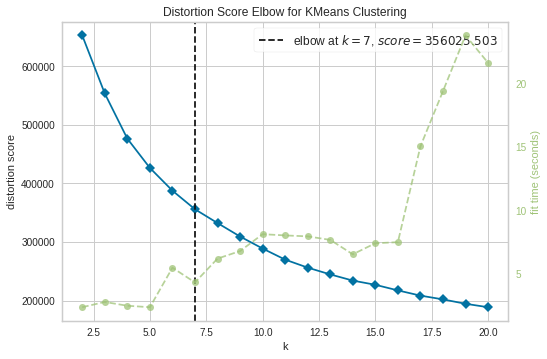

```python
# Visualize performance of KMeans at various values k (distortion score to evaluate KMeans)
model = KMeans()
visualizer = KElbowVisualizer(model, k=(2, 21))

visualizer.fit(feat_scaled)
visualizer.show();
```

```
No. Clusters: 2, Silhouette Score: 0.205, Change from Previous Cluster: 0.0
No. Clusters: 3, Silhouette Score: 0.247, Change from Previous Cluster: 0.042
No. Clusters: 4, Silhouette Score: 0.246, Change from Previous Cluster: -0.001
No. Clusters: 5, Silhouette Score: 0.227, Change from Previous Cluster: -0.019
No. Clusters: 6, Silhouette Score: 0.231, Change from Previous Cluster: 0.004
No. Clusters: 7, Silhouette Score: 0.24, Change from Previous Cluster: 0.009
No. Clusters: 8, Silhouette Score: 0.242, Change from Previous Cluster: 0.002
No. Clusters: 9, Silhouette Score: 0.255, Change from Previous Cluster: 0.013
```

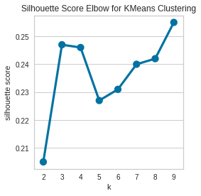

```python
# Evaluate KMeans at various values k
optimal_kmeans(feat_scaled, 2, 10)
```

1st plot shows an elbow at k=7 and 2nd shows k=9

**Visualize clusters with t-SNE**

```
(               0         1         2         3         4         5  Cluster
 0      -0.070845 -0.748782 -1.322188 -1.158742 -0.285653  0.056379        3
 1       0.315956  1.335503 -0.611508  0.863005  1.212924  2.577551        5
 2      -1.054149  1.335503 -0.611508  0.863005 -1.034942 -0.195739        2
 3       0.735578 -0.748782 -0.611508  0.863005 -1.034942 -0.195739        6
 4      -1.332436  1.335503  0.099172  0.863005 -0.660298  0.938789        2
 ...          ...       ...       ...       ...       ...       ...      ...
 131204  0.674731 -0.748782  0.572959  0.863005  1.212924  1.443023        5
 131205  0.902108 -0.748782  1.283639 -1.158742 -1.034942  1.064848        4
 131206 -0.826771 -0.748782  1.283639 -1.158742  1.212924  0.308496        0
 131207 -1.332436  1.335503  0.572959  0.863005 -0.660298  1.064848        2
 131208  0.229913 -0.748782  0.099172  0.863005  1.212924 -0.321797        1

 [131209 rows x 7 columns], array([3, 5, 2, ..., 0, 2, 1], dtype=int32))
```

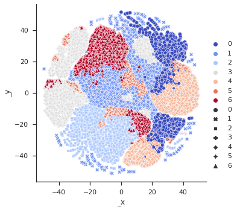

```python
kmeans(feat_scaled, 7)
```

These clusters are pretty messy. I would not feel very confident assigning customers to clusters on the basis of this feature set.

### **Perform KMeans clustering on RFM-like features**

Now I'll try the same thing with the first subset of features: number of orders, mean lag between orders, and mean number of products per order.

```python
# Drop unwanted features
features_fewer = features.drop(['med_hour', 'peakday_rate', 'peaktime_rate'], axis=1)

# Scale selected features
scaler = StandardScaler()
feat_few_scaled = scaler.fit_transform(features_fewer)

# Convert to DataFrame
feat_few_scaled = pd.DataFrame(feat_few_scaled)
```

Determine best value for k

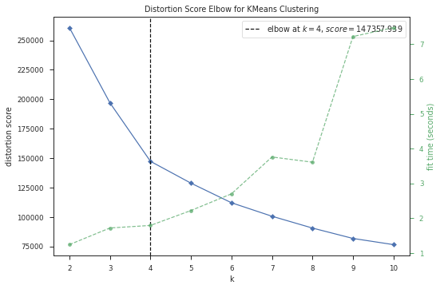

```python
# Evaluate KMeans for various values k
# This method uses distortion score to evaluate KMeans
sns.set_context('paper')
model = KMeans()
visualizer = KElbowVisualizer(model, k=(2, 11))

visualizer.fit(feat_few_scaled)
visualizer.show(outpath='elbow_plot_disto.png', dpi=300);
```

```
No. Clusters: 2, Silhouette Score: 0.333, Change from Previous Cluster: 0.0
No. Clusters: 3, Silhouette Score: 0.344, Change from Previous Cluster: 0.011
No. Clusters: 4, Silhouette Score: 0.349, Change from Previous Cluster: 0.005
No. Clusters: 5, Silhouette Score: 0.32, Change from Previous Cluster: -0.029
No. Clusters: 6, Silhouette Score: 0.329, Change from Previous Cluster: 0.009
No. Clusters: 7, Silhouette Score: 0.321, Change from Previous Cluster: -0.008
No. Clusters: 8, Silhouette Score: 0.313, Change from Previous Cluster: -0.008
No. Clusters: 9, Silhouette Score: 0.305, Change from Previous Cluster: -0.008
No. Clusters: 10, Silhouette Score: 0.292, Change from Previous Cluster: -0.013
```

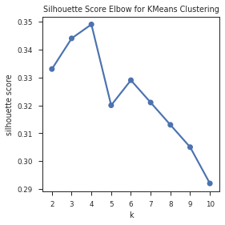

```python
# Evaluate KMeans for various values k
# This method uses silhouette score to evaluate KMeans
optimal_kmeans(feat_few_scaled, 2, 11)
```

Both metrics point to k=4 as the best option. Once again, I'll visualize 3, and 4 clusters for comparison.

Visualize clusters with t-SNE

```
(               0         1         2  Cluster
 0      -0.070845 -0.285653  0.056379        2
 1       0.315956  1.212924  2.577551        0
 2      -1.054149 -1.034942 -0.195739        2
 3       0.735578 -1.034942 -0.195739        2
 4      -1.332436 -0.660298  0.938789        0
 ...          ...       ...       ...      ...
 131204  0.674731  1.212924  1.443023        0
 131205  0.902108 -1.034942  1.064848        2
 131206 -0.826771  1.212924  0.308496        1
 131207 -1.332436 -0.660298  1.064848        0
 131208  0.229913  1.212924 -0.321797        1

 [131209 rows x 4 columns], array([2, 0, 2, ..., 1, 0, 1], dtype=int32))
```

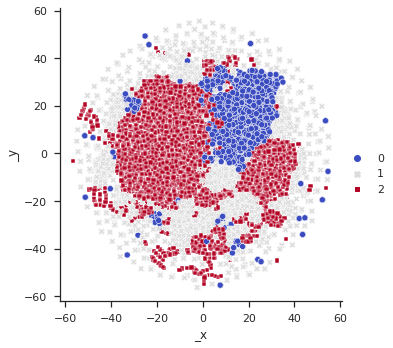

```python
# Plot clusters for k=3
kmeans(feat_few_scaled, 3)
```

```
(               0         1         2  Cluster
 0      -0.070845 -0.285653  0.056379        0
 1       0.315956  1.212924  2.577551        3
 2      -1.054149 -1.034942 -0.195739        0
 3       0.735578 -1.034942 -0.195739        2
 4      -1.332436 -0.660298  0.938789        0
 ...          ...       ...       ...      ...
 131204  0.674731  1.212924  1.443023        3
 131205  0.902108 -1.034942  1.064848        2
 131206 -0.826771  1.212924  0.308496        1
 131207 -1.332436 -0.660298  1.064848        0
 131208  0.229913  1.212924 -0.321797        1

 [131209 rows x 4 columns], array([0, 3, 0, ..., 1, 0, 1], dtype=int32))
```

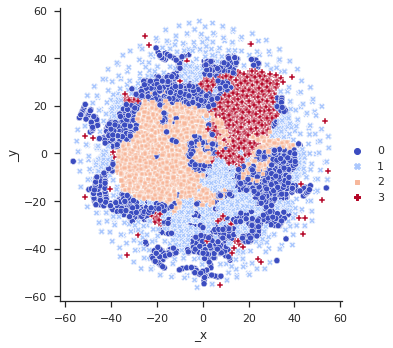

```python
# Plot clusters for k=4
kmeans(feat_few_scaled, 4)
```

The clusters are most easily separable at k=3. Using these features, I think I can get some useful cluster assignments to give to a marketing team.

For the sake of being thorough, I'll also try the remaining features.

### **Perform KMeans clustering with remaining features**

**Determine best value for k**

```python
# Select remaining features
features_dt = features.loc[:, ['med_hour', 'peakday_rate', 'peaktime_rate']]

# Scale and convert to DataFrame
scaler = StandardScaler()
feat_dt_scaled = scaler.fit_transform(features_dt)
feat_dt_scaled = pd.DataFrame(feat_dt_scaled)
```

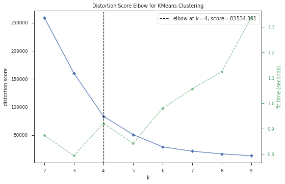

```python
# Evaluate KMeans for various values k
# This method uses distortion score to evaluate KMeans
model = KMeans()
visualizer = KElbowVisualizer(model, k=(2, 10))

visualizer.fit(feat_dt_scaled)
visualizer.show();
```

```
No. Clusters: 3, Silhouette Score: 0.533, Change from Previous Cluster: 0.0
No. Clusters: 4, Silhouette Score: 0.648, Change from Previous Cluster: 0.115
No. Clusters: 5, Silhouette Score: 0.717, Change from Previous Cluster: 0.069
No. Clusters: 6, Silhouette Score: 0.767, Change from Previous Cluster: 0.05
No. Clusters: 7, Silhouette Score: 0.729, Change from Previous Cluster: -0.038
No. Clusters: 8, Silhouette Score: 0.709, Change from Previous Cluster: -0.02
```

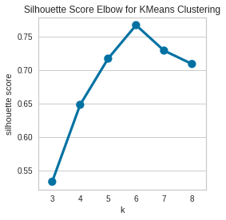

```python
# Evaluate KMeans for various values k
# This method uses silhouette score to evaluate KMeans
optimal_kmeans(feat_dt_scaled, 3, 9)
```

Distortion score points to 4 cluster, while silhouette score indicates 6 would be best. I'll try 4 and 6 clusters to be safe.

**Visualize clusters with t-SNE**

```
(               0         1         2  Cluster
 0      -1.322188 -0.748782 -1.158742        3
 1      -0.611508  1.335503  0.863005        1
 2      -0.611508  1.335503  0.863005        1
 3      -0.611508 -0.748782  0.863005        0
 4       0.099172  1.335503  0.863005        1
 ...          ...       ...       ...      ...
 131204  0.572959 -0.748782  0.863005        0
 131205  1.283639 -0.748782 -1.158742        2
 131206  1.283639 -0.748782 -1.158742        2
 131207  0.572959  1.335503  0.863005        1
 131208  0.099172 -0.748782  0.863005        0

 [131209 rows x 4 columns], array([3, 1, 1, ..., 2, 1, 0], dtype=int32))
```

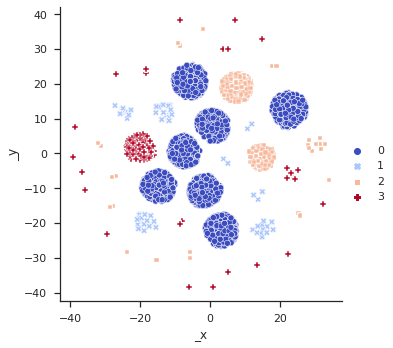

```python
# Plot clusters for k=4
kmeans(feat_dt_scaled, 4)
```

[output not shown]

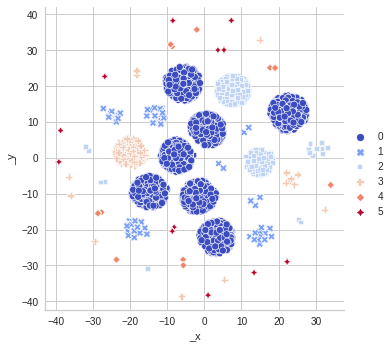

```python
# Plot clusters for k=6
kmeans(feat_dt_scaled, 6)
```

These clusters are terrible! I'm sticking with the first subset of features, which are closest to the features used in an RFM analysis.

### **Create plot for best clusters**

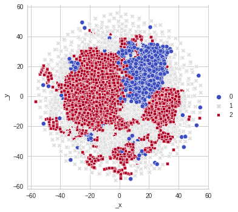

```python
# Extract clusters
k3 = kmeans(feat_few_scaled, 3)
```

```python
# Convert clusters to DataFrame with appropriate index and column names
cluster_df = pd.DataFrame(k3[0])
cluster_df.index = features_fewer.index
cluster_df.columns = ['Number of Orders', 'Avg. Lag Between Orders',
                      'Avg. # Products Per Order', 'Cluster']
cluster_df.head()
```

| user_id | Number of Orders | Avg. Lag Between Orders | Avg. # Products Per Order | Cluster |
| --- | --- | --- | --- | --- |
| 1 | -0.070845 | -0.285653 | 0.056379 | 2 |
| 2 | 0.315956 | 1.212924 | 2.577551 | 0 |
| 5 | -1.054149 | -1.034942 | -0.195739 | 2 |
| 7 | 0.735578 | -1.034942 | -0.195739 | 2 |
| 8 | -1.332436 | -0.660298 | 0.938789 | 0 |

```python
# Reshape data for snake plot
cluster_melt = pd.melt(cluster_df.reset_index(),
                       id_vars=['user_id', 'Cluster'],
                       value_vars=['Number of Orders',
                                   'Avg. Lag Between Orders',
                                   'Avg. # Products Per Order'],
                       var_name='Metric',
                       value_name='Value')
```

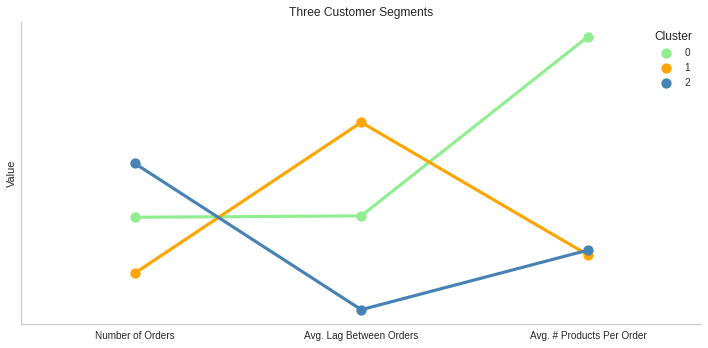

```python
# Create snake plot
palette = ['lightgreen', 'orange', 'steelblue']
plt.figure(figsize=(10,5))
sns.pointplot(x='Metric', y='Value', data=cluster_melt, hue='Cluster',
              palette=palette)
plt.xlabel('')
plt.ylabel('Value')
plt.yticks([])
plt.title('Three Customer Segments')
sns.despine()
plt.tight_layout()
plt.savefig('snake_plot.png', dpi=300, pad_inches=2.0)
plt.show();
```

The snake plot above summarizes what we know about each cluster. Keep in mind that the values on the y-axis are standardized, so they're not in units that are easy to understand. That's why I've hidden them. Think instead in terms of small, medium, and large numbers of orders, lags, and products per order.

```python
# Redo DataFrame for smaller snake plot
cluster_df = pd.DataFrame(k3[0])
cluster_df.index = features_fewer.index
cluster_df.columns = ['Orders', 'Lag',
                      'Products', 'Cluster']
cluster_df.head()
```

| user_id | Orders | Lag | Products | Cluster |
| --- | --- | --- | --- | --- |
| 1 | -0.070845 | -0.285653 | 0.056379 | 2 |
| 2 | 0.315956 | 1.212924 | 2.577551 | 0 |
| 5 | -1.054149 | -1.034942 | -0.195739 | 2 |
| 7 | 0.735578 | -1.034942 | -0.195739 | 2 |
| 8 | -1.332436 | -0.660298 | 0.938789 | 0 |

```python
# Reshape data for smaller snake plot
cluster_melt = pd.melt(cluster_df.reset_index(),
                       id_vars=['user_id', 'Cluster'],
                       value_vars=['Orders',
                                   'Lag',
                                   'Products'],
                       var_name='Metric',
                       value_name='Value')
```

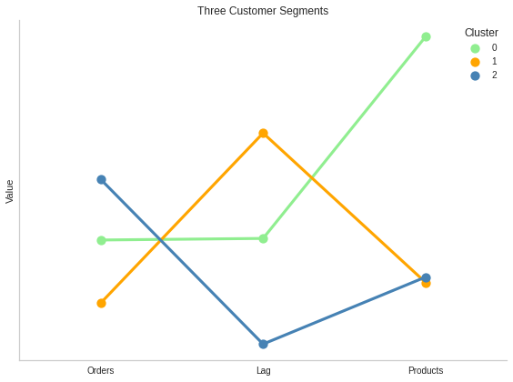

```python
# Create snake plot
palette = ['lightgreen', 'orange', 'steelblue']
plt.figure(figsize=(8,6))
sns.pointplot(x='Metric', y='Value', data=cluster_melt, hue='Cluster',
              palette=palette)
plt.xlabel('')
plt.ylabel('Value')
plt.yticks([])
plt.title('Three Customer Segments')
sns.despine()
plt.tight_layout()
plt.savefig('snake_plot_small.png', dpi=300, pad_inches=2.0)
plt.show();
```

### **Conclusion**

Here’s what I would recommend to a marketing team based on this plot:

- **Cluster 2**: These are - *favorite customers*. They use Instacart a lot and make medium-sized orders. Marketing for these customers could focus on maintaining their loyalty while encouraging them to place orders that bring in more revenue for the company (whether that means more items, more expensive items, etc.).
- **Cluster 0**: These customers don’t use Instacart as often, but when they do, they place *big orders*. Of course we can focus on turning them into more frequent users, and depending on exactly how Instacart generates revenue from orders, we might nudge them to make more frequent, smaller orders, or keep making those big orders.
- **Cluster 1:** This is the segment where we have the most room for improvement. They have tried Instacart, but they don’t use it often, and they don’t purchase many items. A marketing strategy for these folks could focus on increasing order frequency, size, or both.

**Let's look at products, aisles and departments:**

prepare data

```python
order_products_train_df.drop(['add_to_cart_order', 'reordered', 'order_number',
                              'order_dow',	'order_hour_of_day',
                              'days_since_prior_order'], axis=1, inplace=True)
```

```python
order_products_train_df.head(1)
```

|  | order_id | product_id | user_id | eval_set |
| --- | --- | --- | --- | --- |
| 0 | 1 | 49302 | 112108 | train |

```python
order_products_train_df = pd.merge(order_products_train_df, products_df, on='product_id', how='left')
order_products_train_df = pd.merge(order_products_train_df, aisles_df, on='aisle_id', how='left')
order_products_train_df = pd.merge(order_products_train_df, departments_df, on='department_id', how='left')

order_products_train_df.head(1)
```

|  | order_id | product_id | user_id | eval_set | product_name | aisle_id | department_id | aisle | department |
| --- | --- | --- | --- | --- | --- | --- | --- | --- | --- |
| 0 | 1 | 49302 | 112108 | train | Bulgarian Yogurt | 120 | 16 | yogurt | dairy eggs |

```python
cluster_df.reset_index(level=0, inplace=True)
cluster_df.head()
```

[output not shown]

```python
cluster_df.drop(['Orders',	'Lag',	'Products'], axis=1, inplace=True)
```

```python
order_products_train_df = pd.merge(order_products_train_df, cluster_df, on='user_id', how='left')

order_products_train_df.head(1)
```

|  | order_id | product_id | user_id | eval_set | product_name | aisle_id | department_id | aisle | department | index | Cluster |
| --- | --- | --- | --- | --- | --- | --- | --- | --- | --- | --- | --- |
| 0 | 1 | 49302 | 112108 | train | Bulgarian Yogurt | 120 | 16 | yogurt | dairy eggs | 71234 | 1 |

**aisle**

```python
order_products_train_df.groupby('aisle')['Cluster'].value_counts().sort_values()[:5]
```

```
aisle                Cluster
baby accessories     1           69
frozen juice         1           70
baby bath body care  1           97
                     2           98
frozen juice         2          105
Name: Cluster, dtype: int64
```

```python
order_products_train_df['aisle'].value_counts().sort_values()[:5]
```

```
frozen juice           294
baby accessories       306
baby bath body care    328
kitchen supplies       448
ice cream toppings     504
Name: aisle, dtype: int64
```

```python
order_products_train_df['aisle'].value_counts().idxmin()
```

```
'frozen juice'
```

```python
order_products_train_df[(order_products_train_df['Cluster'] == 1)]['aisle'].value_counts().idxmin()
```

```
'baby accessories'
```

**department**

```python
order_products_train_df.groupby('department')['Cluster'].value_counts().sort_values()[:5]
```

```
department  Cluster
bulk        1          397
            0          454
            2          508
other       0          567
            1          570
Name: Cluster, dtype: int64
```

```python
order_products_train_df['department'].value_counts().sort_values()[:10]
```

```
bulk              1359
other             1795
pets              4497
alcohol           5598
missing           8251
international    11902
babies           14941
personal care    21570
breakfast        29500
meat seafood     30307
Name: department, dtype: int64
```

```python
order_products_train_df[(order_products_train_df['Cluster'] == 1)]['department'].value_counts().sort_values()[:10]
```

```
bulk              397
other             570
pets             1430
missing          1957
alcohol          2283
babies           2808
international    3454
personal care    7557
breakfast        8763
meat seafood     9150
Name: department, dtype: int64
```

```python
order_products_train_df['department'].value_counts().idxmin()
```

```
'bulk'
```

```python
order_products_train_df[(order_products_train_df['Cluster'] == 1)]['department'].value_counts().idxmin()
```

```
'bulk'
```

**product_name**

```python
order_products_train_df.groupby('product_name')['Cluster'].value_counts().sort_values()[:5]
```

```
product_name                                 Cluster
with a Splash of Pineapple Coconut Water     2          1
De Mexico Bottle                             0          1
Organic Peas & Brown Rice Stage 2 Baby Food  1          1
Organic Peas Please Garden Herb              0          1
Organic Pecan Pieces                         1          1
Name: Cluster, dtype: int64
```

```python
order_products_train_df['product_name'].value_counts().sort_values()[:10]
```

```
Plain Golden Toasted Bread Crumbs                                           1
Organic Raw Fit High Protein For Weight Loss Powdered Dietary Supplement    1
Organic Ground Thyme                                                        1
Original Cactus Water                                                       1
Intensive Care Unscented Moisturizing Lotion                                1
Imported Classic Pure Mild Olive Oil                                        1
White Merlot                                                                1
Veggies First Pumpkin Banana Puree                                          1
Ultra Moisture Coconut Oasis Body Wash                                      1
Tender Care Diapers Jumbo Pack                                              1
Name: product_name, dtype: int64
```

```python
order_products_train_df[(order_products_train_df['Cluster'] == 1)]['product_name'].value_counts().sort_values()[:10]
```

```
Plain Golden Toasted Bread Crumbs             1
Cough Syrup                                   1
Fire Roasted Whole Green Mild Green Chiles    1
Ruby Grapefruit Segments                      1
Honey Wheat Crackers                          1
Sesame Cooking Sauce                          1
Large Gluten-Free Coconut Macaroons           1
Organic Mulling Spices                        1
Pecan Nut Cakes                               1
Cucumber Dill Lentil Chips                    1
Name: product_name, dtype: int64
```

### **Conclusion**

Как и ожидалось, смотря на представленныуе ниже данные, самые редкие продукты и их разделы представлены в 1 кластере (редкие покупатели с большими перерывами между покупками и маленькими покупками). Данные были просмотрены по всем кластерам.

- aisle -

  ```
        frozen juice           294
        baby accessories       306
        baby bath body care    328
  ```

- department -

  ```
        bulk              1359
        other             1795
        pets              4497
  ```

**Ideas:**

- Provide rewards for every N-th order to increase loyalty. *(for claster 2)*
- Offer discounts or provide rewards for at least 1st 4 orders. Target with weekly remainders and local specials. *(for claster 0)*
- Keep monitoring cluster for sudden changes in behavior. *(for claster 1)*
- (Outliers) -- Occasional shoppers --> Prioritaze targeting this cluster, can -> target with weekly remainders and local specials.